# new

Chiffon

Friday, May 08, 2015

[interactive chart not shown]

点这里看完整的reveal展示: http://lchiffon.github.io/reveal_slidify/train1.html?theme=sky#/slide-1

## 简介

reveal.js是一个slides的框架,本文是对于在slidify包下reveal.js的实现:

- 基本上所有的slidify默认的形式可以直接放在reveal.js中实现
- slidify默认框架为io2012
- 稍大的字体
- 默认居中显示各个元素
- 较好的过渡,动态效果
- [英文教程](http://lchiffon.github.io/reveal_slidify/train.html)

## Outlines

### 不同的小trick

- YAML
- 纵向slides
- 总览和放大
- 动态效果
- 背景
- 其他控件

### YAML

超长的YAML,不过好消息是基本不需要做太多的更改…

```
    ---
    title: Checking Reveal.js
    author: Ramnath Vaidyanathan
    mode : selfcontained
    framework: revealjs
    hitheme : zenburn
    revealjs:
      theme:  sky # {solarized,Black,White,League,sky,Beige,Simple,Serif, Night,Moon}
      transition: slide # {fade/slide/convex/concave/zoom}
      center: "true"
    url: {lib: "."}
    bootstrap:
      theme: amelia
    navbar:
      title: Slidify
      items:
        - {item: Home, href: index,  icon: home}
        - {item: "Start", href: start, icon: signin}
        - {item: Author, href: about, icon: pencil}
       - {item: Style, href: style, icon: hand-right, class: dropdown,
            dropdown: true, menu: [
            {item: io2012, href: 'samples/intro'},
            {item: deck.js, href: 'samples/deck.js'},
            {item: shower, href: 'samples/shower'},
             {item: landslide, href: 'samples/landslide'}
            ]
         }
        - {item: Customize, href: customize, icon: gift}
        - {item: Extend, href: extend, icon: cogs}
       - {item: Publish, href: publish, icon: github}
    ---

    <script src="http://ajax.googleapis.com/ajax/libs/jquery/1.9.1/jquery.min.js"></script>
```

## Vertical Slides

### 纵向slides

纵向slides指的是在左右换页的情况下增加另一个维度的换页,上下换页

基本使用方法如下:

在第一页使用&vertical来声明:

```
   --- &vertical

   ## Vertical Slides
   ### 纵向slides
   ...
```

在之后的页面使用 `***` 而不是 `---`:

```
  ***
  ## 这是一个子页
```

总的来说就是这样:

```
   --- &vertical

   ## Vertical Slides
   ### 纵向slides

   ***
   ## 这是一个子页

   ***
   ## 子页2
```

### 总览和放大

在任何一页,按下ESC键会进入总览,可以从这里选择你需要查看的页面.

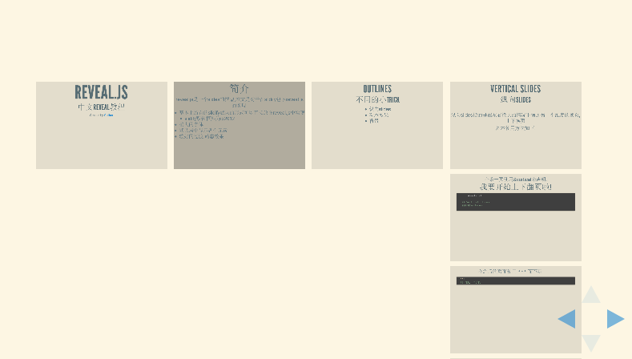

### 总览和放大

在任何一页,ALT加鼠标左键可以查看该点处的放大效果,这个功能是从[zoom.js](http://lab.hakim.se/zoom-js)实现的,再次alt点击任意一点恢复原先的视角.

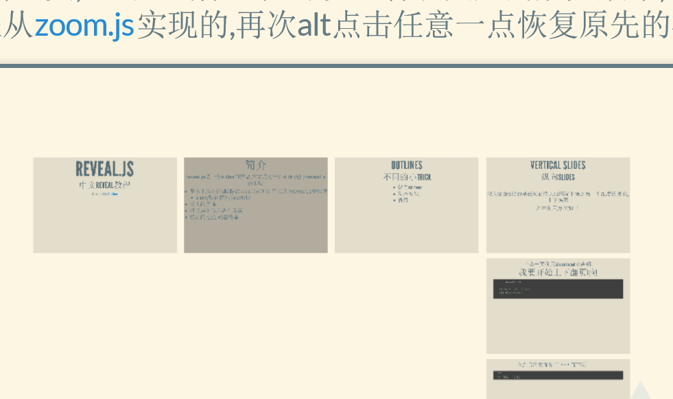

## TRANSITION STYLES

可以自由的设置切换页面的方式,点击下面的选项来查看不同的切换效果

Cube - Page - Concave - Zoom - Linear - Fade - None - Default

## 更改切换的方式:

在Rmd文件的YAML部分修改slides的切换方式:

```
    transition: slide # {fade/slide/convex/concave/zoom}
```

- 本案使用slide来实现切换的
- 可以修改Rmd文件并slides出新的slides
- 比如:

```
    transition: convex
```

## 主题

Reveal.js支持以下所有主题:

sky - Beige - Simple - Serif - Night - Default - Solarized - Moon

## 在slidify中修改主题

在Rmd文件的YAML部分修改slides的主题:

```
      theme: solarized
```

```
      theme: White
```

## 更改背景颜色

- alert

```
    --- ds:alert
```

- Blackout

```
    --- ds:blackout
```

- Soothe

```
    --- ds:soothe
```

## 其他小控件

### 逐步进入的条目

- 与io2012相同,使用`>-`
- 坏消息是在slides的**最后**需要加一段JS
- 或者在每次使用这个功能以后加入后面的JS

```
    > - any type
    > - of view
    > - __fragments__
    <script>
    $('ul.incremental li').addClass('fragment')
    </script>
```

### 动态效果

```
    > - Point 1
    > - .highlight-red Point 2
    > - .grow Point 3
    <script>
    $('ul.incremental li').addClass('fragment')
    </script>
```

## 最后的总结

### reveal.js的优点:

- 支持大部分熟悉的slidify语法
- Chunks
- Markdown
- Knitr
- Html

### 适合演讲

- 大字体适合做report的时候使用
- 绚丽的动态切换效果
- 不同的主题供以使用
- 完美支持中文
- 移动端可用

### reveal.js的缺点:

- 不适合讲课的地方
- codes显示较小
- 动态切换和主题容易干扰学生注意力
- 一些功能需要加JS代码
- 与io2012不同,首页需要自己写,而不是自动生成